# Total Nitrogen

L. Patterson and J. Fay

Spring, 2018

# Exploratory Data Analysis

## Prep the workspace by installing (if needed) and loading libraries

```r
library(dataRetrieval); library(EGRET)
library (ggplot2);  library(trend); library(lubridate)
library(dplyr); library(magrittr); library(leaflet)
```

## Load in the water quality *site* data

```r
#set working directlry
swd <- "c:/Users/lap19/Documents/Class/Data Boot Camp/Unit3 Water Quality/"

#read in the csv files
sites <- read.csv(paste0(swd,"station.csv"), sep=',',header=TRUE); dim(sites)
```

```
## [1] 91 36
```

```r
  sites[1:3,]
```

```
##   OrganizationIdentifier                   OrganizationFormalName
## 1                USGS-NC USGS North Carolina Water Science Center
## 2                USGS-NC USGS North Carolina Water Science Center
## 3                USGS-NC USGS North Carolina Water Science Center
##   MonitoringLocationIdentifier                    MonitoringLocationName
## 1              USGS-0209330990     BROOKS LAKE TRIB NR BROWNS SUMMIT, NC
## 2              USGS-0209331325      CANDY CR AT SR2700 NR MONTICELLO, NC
## 3              USGS-0209437825 SMITH BRANCH UPPER TRIB NR MONTICELLO, NC
##   MonitoringLocationTypeName MonitoringLocationDescriptionText
## 1                     Stream
## 2                     Stream
## 3                     Stream
##   HUCEightDigitCode DrainageAreaMeasure.MeasureValue
## 1           3030002                           0.0600
## 2           3030002                           1.1000
```

[output cut: 61 more lines]

```r
  dim(sites)
```

```
## [1] 91 36
```

## Plot the sites

Load in the site data and plot a map to see where water quality data were present from this portal.

Let’s play with the data and see what it looks like to subset the data by removing small streams with a drainage area of less than 25 mi2.

```r
#plot sites
map <-  leaflet(data=sites) %>%
    addProviderTiles("CartoDB.Positron") %>%
    addCircleMarkers(~LongitudeMeasure,~LatitudeMeasure,
                     color = "red", radius=3, stroke=FALSE,
                     fillOpacity = 0.8, opacity = 0.8,
                     popup=~MonitoringLocationName)
map
```

[interactive chart not shown]

When we do this, we find there are only 10 sites remaining. This seems really small, so we plot these new sites on the map (blue), overlaying the orginal sites in red.

```r
# subset to only include those with a drainage area exceeding 25 square miles
sites2 <- subset(sites, DrainageAreaMeasure.MeasureValue >= 25); dim(sites2)
```

```
## [1] 10 36
```

```r
#where are sites located?
leaflet(data=sites) %>%
    addProviderTiles("CartoDB.Positron") %>%
    addCircleMarkers(~LongitudeMeasure,~LatitudeMeasure,
                   color = "red", radius=3, stroke=FALSE,
                   fillOpacity = 0.8, opacity = 0.8,
                   popup=~MonitoringLocationName) %>%
    addCircleMarkers(~sites2$LongitudeMeasure,~sites2$LatitudeMeasure,
                 color = "blue", radius=3, stroke=FALSE,
                 fillOpacity = 0.8, opacity = 0.8,
                 popup=~MonitoringLocationName)
```

[interactive chart not shown]

```r
#Notice for Jordan Lake... the two values we will be most interested in are: Haw River at SR 1943 and
#All the names on Jordan Lake are "Jordan Lake"... change popup name to see options
```

We take a closer look at the drainage measurement values and see there are numerous NA values. Clearly, filtering by drainage area will not look. The main point I want to make here is **don’t be afraid to *play* with the data**.

Let’s replot the site map but now change the popup name to see which site names are located within each branch of Jordan Lake.

```r
leaflet(data=sites) %>%
  addProviderTiles("CartoDB.Positron") %>%
  addCircleMarkers(~LongitudeMeasure,~LatitudeMeasure,
                   color = "red", radius=3, stroke=FALSE,
                   fillOpacity = 0.8, opacity = 0.8,
                   popup=~MonitoringLocationIdentifier)
```

[interactive chart not shown]

```r
#reduce columns to those needed
sites <- sites[,c(1,3:4,8:9,12:13)]
```

## Load in the water quality *measurement* data

Once we load in the measurements data, we need to do some cleaning. The first step is to filter the data to what we want to use. For example,

- We want to make sure we are using routine samples and not extreme event sampling (biased for specific occasions and not for estimating annual average load).
- We determine what type of Nitrogen we want to use. From the literature we found that regulations for Nitrogen include: nitrate, nitrite, ammonia and organic forms. Doing some reading about the WQX standards, you learn that Nitrogen, mixed froms incorporates all of the above forms of nitrogen.
- We also want to make sure we are looking at total Nitrogen, so make sure the Results Sample Fraction Text only includes those with Total.

```r
results <- read.csv(paste0(swd,"result.csv"), sep=',',header=TRUE); dim(results)
```

```
## [1] 98590    63
```

```r
  names(results)
```

```
##  [1] "OrganizationIdentifier"
##  [2] "OrganizationFormalName"
##  [3] "ActivityIdentifier"
##  [4] "ActivityTypeCode"
##  [5] "ActivityMediaName"
##  [6] "ActivityMediaSubdivisionName"
##  [7] "ActivityStartDate"
##  [8] "ActivityStartTime.Time"
##  [9] "ActivityStartTime.TimeZoneCode"
## [10] "ActivityEndDate"
## [11] "ActivityEndTime.Time"
## [12] "ActivityEndTime.TimeZoneCode"
## [13] "ActivityDepthHeightMeasure.MeasureValue"
## [14] "ActivityDepthHeightMeasure.MeasureUnitCode"
## [15] "ActivityDepthAltitudeReferencePointText"
```

[output cut: 48 more lines]

```r
#find out what options are present for the Hydrologic Events and Characteristic Name
unique(results$HydrologicEvent);
```

```
## [1] Routine sample              Not Determined (historical)
## [3] Flood                       Storm
## [5] Drought                     Spring breakup
## [7]
## 7 Levels:  Drought Flood Not Determined (historical) ... Storm
```

```r
unique(results$CharacteristicName);
```

```
##  [1] Kjeldahl nitrogen
##  [2] Ammonia and ammonium
##  [3] Inorganic nitrogen (nitrate and nitrite)
##  [4] Organic Nitrogen
##  [5] Orthophosphate
##  [6] Phosphate-phosphorus
##  [7] Phosphorus
##  [8] Nitrogen, mixed forms (NH3), (NH4), organic, (NO2) and (NO3)
##  [9] Nitrate
## [10] Nitrite
## [11] Nitrogen
## [12] Ammonia-nitrogen
## [13] Orthophosphate as P
## [14] Ammonia-nitrogen as N
## [15] Phosphate-phosphorus as P
## [16] Ammonia
## [17] Inorganic nitrogen (nitrate and nitrite) as N
## [18] Orthophosphate as PO4
## 18 Levels: Ammonia Ammonia-nitrogen ... Phosphorus
```

```r
#filter data
nitrogen <-results %>%
          filter(ActivityMediaSubdivisionName=="Surface Water") %>%
          filter(HydrologicEvent != "Storm" & HydrologicEvent != "Flood" & HydrologicEvent != "Spring breakup" & HydrologicEvent != "Drought") %>%
          filter(CharacteristicName=="Nitrogen, mixed forms (NH3), (NH4), organic, (NO2) and (NO3)") %>%
          filter(ResultSampleFractionText=="Total")
dim(nitrogen)
```

```
## [1] 4040   63
```

```r
#check that filters worked
unique(nitrogen$HydrologicEvent); unique(nitrogen$ActivityMediaSubdivisionName)
```

```
## [1] Routine sample              Not Determined (historical)
## 7 Levels:  Drought Flood Not Determined (historical) ... Storm
```

```
## [1] Surface Water
## Levels:  Bulk deposition Surface Water Wet Fall Material
```

```r
unique(nitrogen$CharacteristicName);  unique(nitrogen$ResultSampleFractionText)
```

```
## [1] Nitrogen, mixed forms (NH3), (NH4), organic, (NO2) and (NO3)
## 18 Levels: Ammonia Ammonia-nitrogen ... Phosphorus
```

```
## [1] Total
## Levels:  Bed Sediment Dissolved Suspended Total
```

```r
#reduce to needed columns
nitrogen <- nitrogen[,c(1,7,22,31:35,59:61)]
```

### Detection Limits and Unit Conversion

You may have noticed that many sample sites state “not detected”. This is important data that are not currently being represented. Create a new column and set the value equal to the results, unless it is below the detection limit - in which case set it equal to ½ of the detection limit.

You may also have noted that the total nitrogen was sometimes reported as mg/l or mg/l NO3. We want mg/l. To convert to mg/l, we know the atomic weight of nitrogen is 14.0067 and the molar mass of nitrate anion (NO3) is 62.0049 g/mole. Therefore, to convert between units:

- Nitrate-N (mg/L) = 0.2259 x Nitrate-NO3 (mg/L)
- Nitrate-NO3 (mg/L) = 4.4268 x Nitrate-N (mg/L)

```r
#set data below detection limits equal to 1/2 the detection limit
nitrogen$TotalN <- ifelse(nitrogen$ResultDetectionConditionText=="Not Detected", nitrogen$DetectionQuantitationLimitMeasure.MeasureValue/2, nitrogen$ResultMeasureValue)

#convert mg/l as No3 to mg/l as N
nitrogen$TotalN <- ifelse(nitrogen$ResultMeasure.MeasureUnitCode=="mg/l NO3", nitrogen$TotalN*0.2259, nitrogen$TotalN)
nitrogen$TotalN <- ifelse(nitrogen$DetectionQuantitationLimitMeasure.MeasureUnitCode=="mg/l NO3", nitrogen$TotalN*0.2259, nitrogen$TotalN)
```

## Exploratory Data Analysis

### Merge sites and measurement data together

Currently, site and measurement data are not connected together. However, we may want to show the nitrate values on a map. To do this, we merge the data together based on a unique identifier shared between the two data sets. In this case, it is the *MonitoringLocationIdentifier* column.

```r
nitrogen.data <- merge(sites, nitrogen, by.x="MonitoringLocationIdentifier", by.y="MonitoringLocationIdentifier"); dim(nitrogen.data)
```

```
## [1] 4040   18
```

```r
#create year and month categories. Make a table to see how many samples were collected each year/month
  nitrogen.data$Year <- year(nitrogen.data$ActivityStartDate);                    table(nitrogen.data$Year)
```

```
##
## 1979 1980 1981 1982 1983 1984 1985 1986 1987 1988 1989 1990 1991 1992 1993
##    4   44   48   50   82  154  183   74  124  128  408  242  100   58   53
## 1994 1995 1996 1997 1998 1999 2000 2001 2002 2003 2004 2005 2006 2007 2008
##   54   40   33   32   27   41   51   94  115  142  109   90   90   94  114
## 2009 2010 2011 2012 2013 2014 2015 2016 2017
##  114  115   97  204  196  104   73   78  181
```

```r
  nitrogen.data$Month <- month(nitrogen.data$ActivityStartDate);                  table(nitrogen.data$Month)
```

```
##
##   1   2   3   4   5   6   7   8   9  10  11  12
## 139 284 153 555 278 608 268 623 281 517 110 224
```

### Filter merged data

First we want to know how many sites are collecting data of interest. We find there are 22 sites. Of those sites, we want to know which were collecting data after the Jordan Lake Rules were passed and how much data are being collected at this site.

Based on this, we see several sites stopped collecting data prior to 2009, when the first iteration of Jordan Rules were passed. We also see that some of these sites collected only a few years of data. Remove those sites and plot the remaining sites on the map.

```r
#ED to know which sites to keep or remove
unique.sites <- unique(nitrogen.data$MonitoringLocationIdentifier)
  n.sites <- length(unique.sites)

#Create dataframe of information on: n samples, start year, end year
site.info <- nitrogen.data %>%
  group_by(MonitoringLocationIdentifier) %>%
  summarise(n=n(), StartYear=min(Year), EndYear=max(Year))
site.info <- as.data.frame(site.info)
site.info$Range <- site.info$EndYear-site.info$StartYear
site.info
```

```
##    MonitoringLocationIdentifier   n StartYear EndYear Range
## 1               USGS-0209330990 151      1985    1990     5
## 2               USGS-0209331325 236      1985    1990     5
## 3               USGS-0209437825 270      1985    1990     5
## 4               USGS-0209437850 260      1985    1990     5
## 5                 USGS-02096842  50      1979    1981     2
## 6                 USGS-02096846 263      1988    2017    29
## 7               USGS-0209684980 253      1989    2017    28
## 8                 USGS-02096960 179      1981    2004    23
## 9               USGS-0209699999 255      1991    2017    26
## 10                USGS-02097314  69      1982    2001    19
## 11              USGS-0209741955  75      1982    2002    20
## 12                USGS-02097464 265      1988    2017    29
## 13              USGS-0209749990 252      1988    2017    29
## 14                USGS-02097517  83      1982    2014    32
## 15              USGS-0209768310 262      1992    2017    25
## 16              USGS-0209771550  99      1991    2017    26
## 17              USGS-0209781125  90      2012    2017     5
## 18              USGS-0209782609 106      1999    2017    18
## 19              USGS-0209791010  89      2012    2017     5
## 20              USGS-0209799150 355      1991    2017    26
## 21              USGS-0209801100 256      1991    2017    26
## 22                USGS-02098198 122      1980    1985     5
```

```r
#Limit data to those with more than 10 years data and still operating
site.info <- filter(site.info, Range>=10 & EndYear>=2017); site.info
```

```
##    MonitoringLocationIdentifier   n StartYear EndYear Range
## 1                 USGS-02096846 263      1988    2017    29
## 2               USGS-0209684980 253      1989    2017    28
## 3               USGS-0209699999 255      1991    2017    26
## 4                 USGS-02097464 265      1988    2017    29
## 5               USGS-0209749990 252      1988    2017    29
## 6               USGS-0209768310 262      1992    2017    25
## 7               USGS-0209771550  99      1991    2017    26
## 8               USGS-0209782609 106      1999    2017    18
## 9               USGS-0209799150 355      1991    2017    26
## 10              USGS-0209801100 256      1991    2017    26
```

```r
df <- nitrogen.data[nitrogen.data$MonitoringLocationIdentifier %in% unique(site.info$MonitoringLocationIdentifier), ]; dim(df)
```

```
## [1] 2366   20
```

```r
#Where are they located
leaflet(data=df) %>%  addProviderTiles("CartoDB.Positron") %>%
  addCircleMarkers(~LongitudeMeasure,~LatitudeMeasure,
                   color = "red", radius=5, stroke=FALSE,
                   fillOpacity = 0.8, opacity = 0.8,
                   popup=~MonitoringLocationIdentifier)
```

[interactive chart not shown]

### Plot total nitorgen over time, by month and by year for each site.

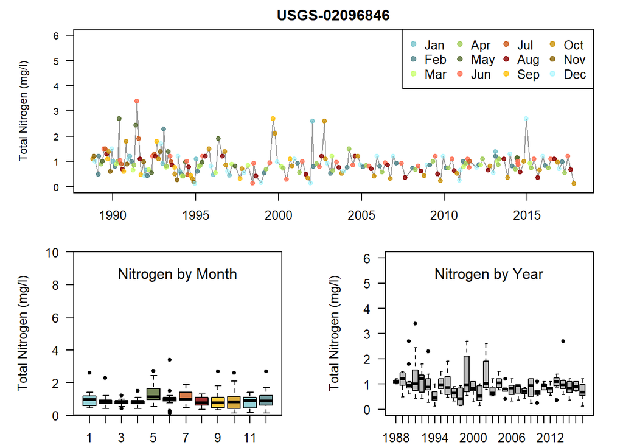

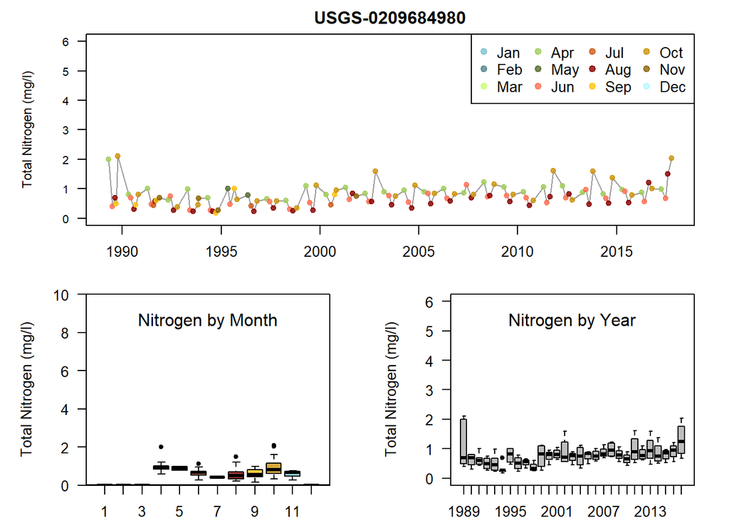

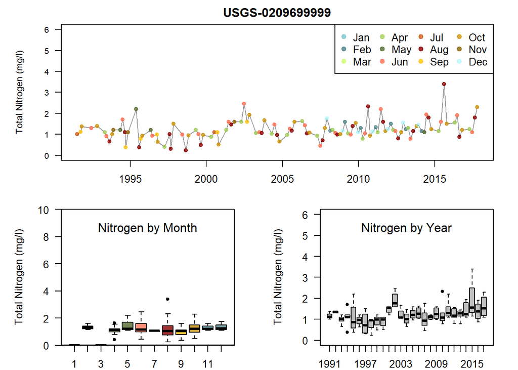

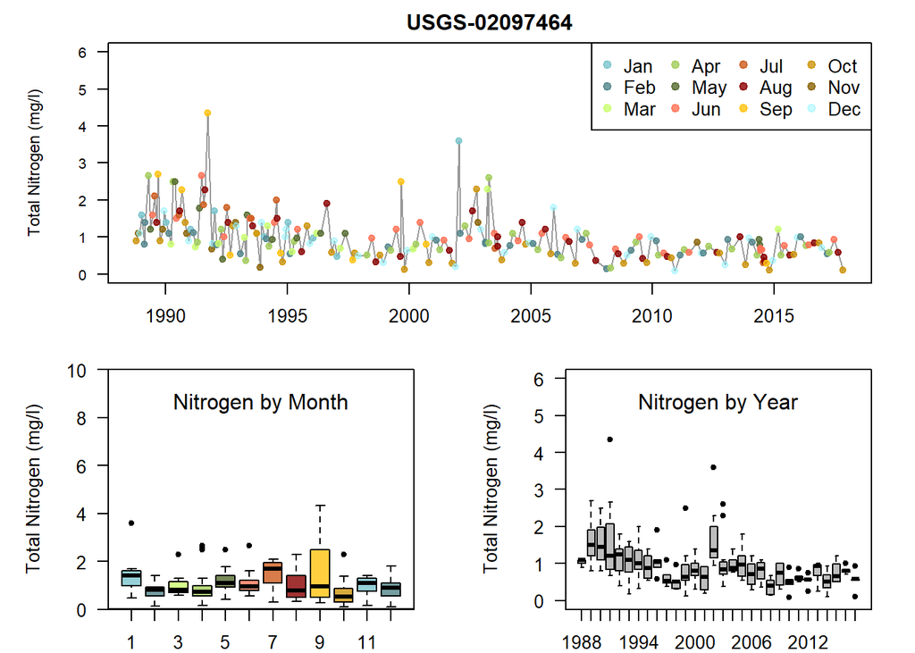

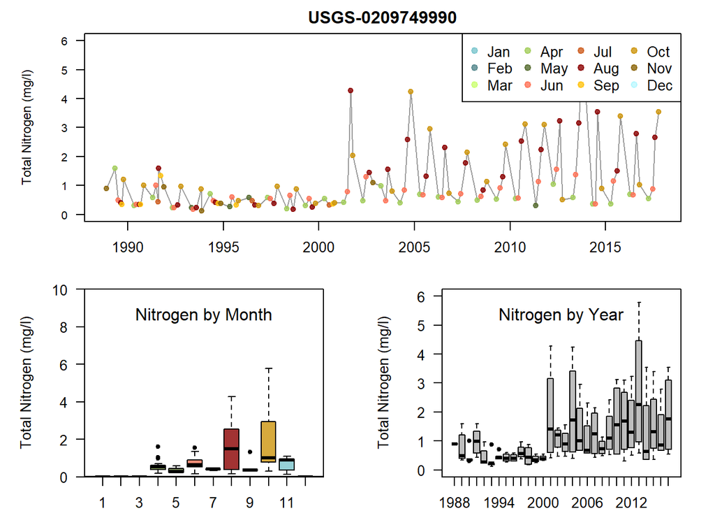

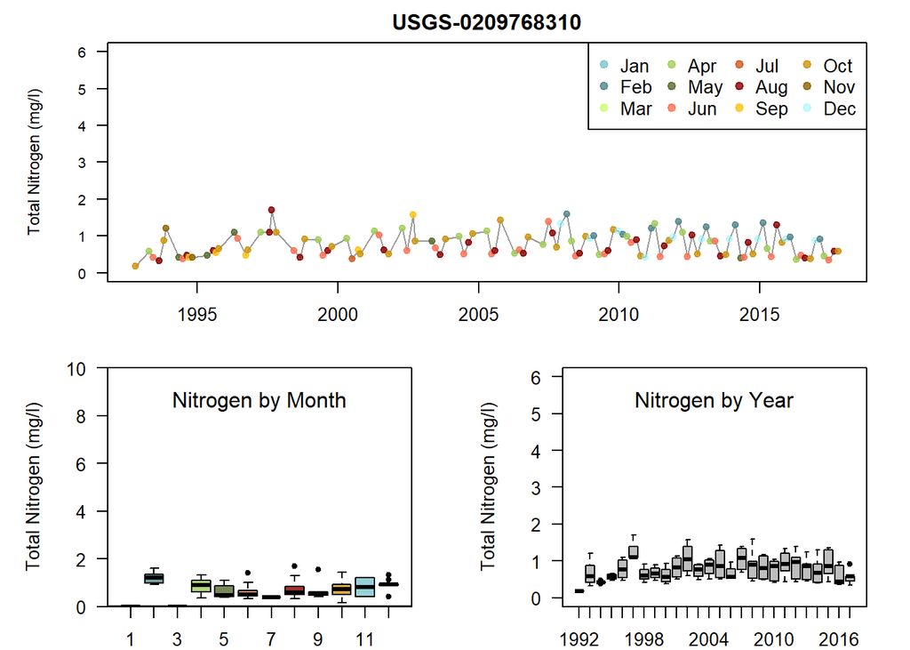

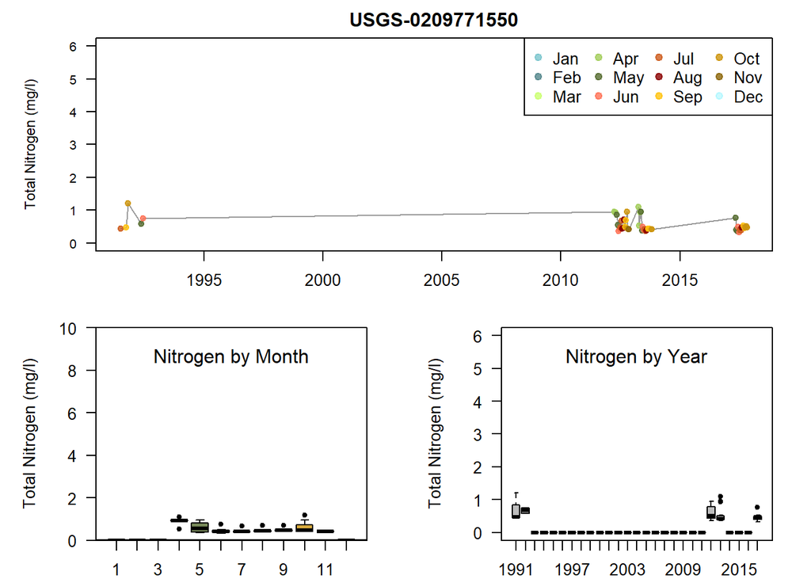

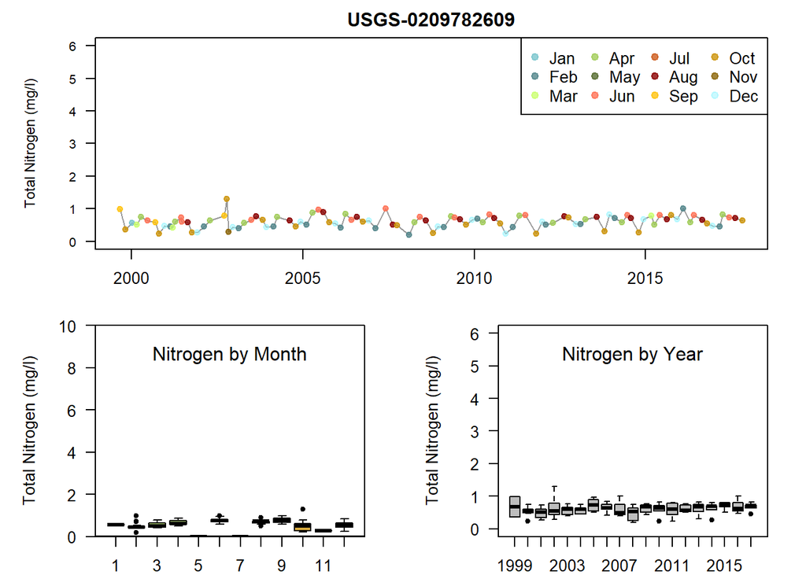

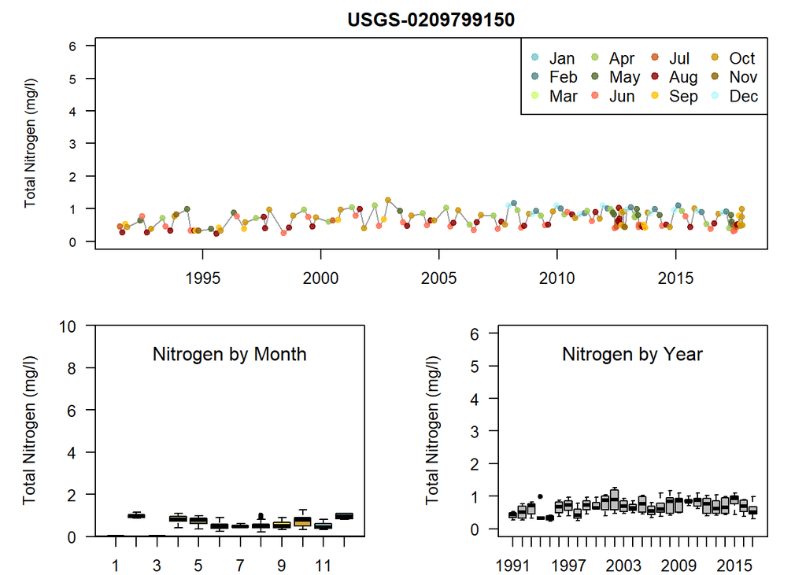

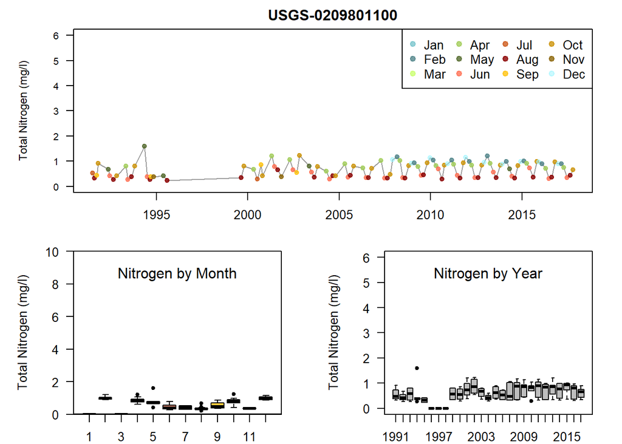

```r
####Plot nitrogen over time at each site
unique.site <- unique(df$MonitoringLocationIdentifier)

#convert activity date into a data
df$Date <- as.Date(df$ActivityStartDate, "%Y-%m-%d")
df$Year <- year(df$Date);   df$Month <- month(df$Date)


i=1
for (i in 1:length(unique.site)){
  zt <- filter(df, MonitoringLocationIdentifier == unique.site[i])

  #group by date - take average of a day
  foo <- zt %>% group_by(Date) %>%
    summarise(AverageN = mean(TotalN, na.rm=TRUE), Year=mean(Year), Month=mean(Month))
  foo <- as.data.frame(foo)

  foo$color <- rgb(0.596,0.961,1,0.5)
  foo$color <- ifelse(foo$Month==1, rgb(0.478,0.772,0.804,0.8), foo$color)
  foo$color <- ifelse(foo$Month==2, rgb(0.325,0.525,0.545,0.8), foo$color)
  foo$color <- ifelse(foo$Month==3, rgb(0.792,1,0.439,0.8), foo$color)
  foo$color <- ifelse(foo$Month==4, rgb(0.635,0.804,0.352,0.8), foo$color)
  foo$color <- ifelse(foo$Month==5, rgb(0.333,0.420,0.184,0.8), foo$color)
  foo$color <- ifelse(foo$Month==6, rgb(1,0.447,0.337,0.8), foo$color)
  foo$color <- ifelse(foo$Month==7, rgb(0.804,0.357,0.114,0.8), foo$color)
  foo$color <- ifelse(foo$Month==8, rgb(0.545,0,0,0.8), foo$color)
  foo$color <- ifelse(foo$Month==9, rgb(1,0.765,0.059,0.8), foo$color)
  foo$color <- ifelse(foo$Month==10, rgb(0.804,0.584,0.047,0.8), foo$color)
  foo$color <- ifelse(foo$Month==11, rgb(0.545,0.396,0.031,0.8), foo$color)

  #create a plot
  par(mfrow=c(1,1))
  layout(matrix(c(1,1,2,3), 2, 2, byrow = TRUE), widths=c(2,2), heights=c(1.5,1.5))
  par(mar = c(2,5,2,2)) #set plot margins

  #Plot single graph on top row
  plot(foo$Date, foo$AverageN, type='n', yaxt="n", main=zt$MonitoringLocationIdentifier[i], ylab="Total Nitrogen (mg/l)", xlab = '', cex.lab=0.9, ylim=c(0,6))
    axis(2, las=2, cex.axis=0.8)
  lines(foo$Date, foo$AverageN, col=rgb(0,0,0,0.4))
  points(foo$Date, foo$AverageN, col=foo$color, cex=0.8, pch=19)

  legend_order <- matrix(1:12,ncol=4,byrow = TRUE)
  legend("topright", c("Jan","Feb","Mar","Apr","May","Jun","Jul","Aug","Sep","Oct","Nov","Dec"),
         pch=19, col=c(rgb(0.478,0.772,0.804,0.8),rgb(0.325,0.525,0.545,0.8),rgb(0.792,1,0.439,0.8),rgb(0.635,0.804,0.352,0.8),rgb(0.333,0.420,0.184,0.8),
                       rgb(1,0.447,0.337,0.8),rgb(0.804,0.357,0.114,0.8),rgb(0.545,0,0,0.8),rgb(1,0.765,0.059,0.8),rgb(0.804,0.584,0.047,0.8),
                       rgb(0.545,0.396,0.031,0.8), rgb(0.596,0.961,1,0.5)), ncol=4)

#Add blank months to foo in case
  blank.months <- as.data.frame(matrix(nrow=12,ncol=5)); colnames(blank.months) <- colnames(foo)
  months.tab <- as.data.frame(table(foo$Month)); colnames(months.tab)<-c("Month","Freq");
  k=1
  for (j in 1:12){
    check <- j;
    check.zt <- subset(months.tab, Month==j)

    if(dim(check.zt)[1]==0){
      blank.months$Month[k]=check;   blank.months$AverageN[k]=0
      k=k+1
    }
  }
  blank.months <- blank.months[!is.na(blank.months$Month),]
  blank.months
  foo.mo <- rbind(foo, blank.months)

  boxplot(foo.mo$AverageN~foo.mo$Month, yaxt="n", ylab="Total Nitrogen (mg/l)", ylim=c(0,10), yaxs='i',
          col=c(rgb(0.478,0.772,0.804,0.8),rgb(0.325,0.525,0.545,0.8),rgb(0.792,1,0.439,0.8),rgb(0.635,0.804,0.352,0.8),rgb(0.333,0.420,0.184,0.8),
                rgb(1,0.447,0.337,0.8),rgb(0.804,0.357,0.114,0.8),rgb(0.545,0,0,0.8),rgb(1,0.765,0.059,0.8),rgb(0.804,0.584,0.047,0.8)), pch=19, cex=0.7)
  axis(2, las=2)
  mtext("Nitrogen by Month", side=3, line=-2)
  abline(h=0.01, col="black", lwd=1)


  #Add blank years to foo in case
  year.tab <- as.data.frame(table(foo$Year)); colnames(year.tab)<-c("Year","Freq");
  year.tab$Year <- as.numeric(as.character(year.tab$Year))
  row.no <- max(year.tab$Year)-min(year.tab$Year)

  blank.years <- as.data.frame(matrix(nrow=row.no,ncol=5)); colnames(blank.years) <- colnames(foo)

  k=1

  for (j in min(year.tab$Year):max(year.tab$Year)){
    check <- j;
    check.zt <- subset(year.tab, Year==check)

    if(dim(check.zt)[1]==0){
      blank.years$Year[k]=check;   blank.years$AverageN[k]=0
      k=k+1
    }
  #print(check)
  }
  blank.years <- blank.years[!is.na(blank.years$Year),]
  blank.years

  foo.yr <- rbind(foo, blank.years)

  boxplot(foo.yr$AverageN~foo.yr$Year, yaxt="n", ylab="Total Nitrogen (mg/l)", ylim=c(0,6), col="grey", pch=19, cex=0.7)
  axis(2, las=2)
  mtext("Nitrogen by Year", side=3, line=-2)
  abline(h=10, col="red", lwd=2, lty=4)

  #print(i)
}
```

### Plot the 2017 Nitrogen year on leaflet

Let’s show the amount of Nitrogen coming from each site based on the size of the circle.

```r
nitrogen.data$Year <- year(nitrogen.data$ActivityStartDate)
last.year <- filter(nitrogen.data, Year==2017)
last.year.n <- last.year %>%
  group_by(MonitoringLocationIdentifier) %>%
  summarize(AveN = mean(TotalN, na.rm=T), LongitudeMeasure = mean(LongitudeMeasure), LatitudeMeasure = mean(LatitudeMeasure))
last.year.n <- as.data.frame(last.year.n)

last.year.n$AveN <- round(last.year.n$AveN,3)

leaflet(data=last.year.n) %>%
  addProviderTiles("Esri.WorldTopoMap") %>%
  addCircleMarkers(~LongitudeMeasure,~LatitudeMeasure,
                   color = "red", radius=~AveN*5, stroke=FALSE,
                   fillOpacity = 0.6, opacity = 0.8,
                   popup=~paste0(MonitoringLocationIdentifier, "<br>",
                          "Average 2017 N: ", AveN, " mg/l"))
```

[interactive chart not shown]

## Compare the Nitrogen Load with Thresholds

The water quality data reports Nitrogen as mg/l. In order to convert to an annual load (lbs/yr), we need to know the volume of water flowing through each site. Go to the NWIS Mapper to find which USGS gauges are closest to the Haw River Arm (1 site) and the New Hope Arm (3 sites).

### Load NWIS data for Haw River

```r
#USGS-0209699999 is the arm of the Haw River and there is a USGS stream gauge site nearby: USGS 02096960
#Identify gauge to download
siteNo <- '02096960'
#Identify parameter of interest: https://help.waterdata.usgs.gov/code/parameter_cd_query?fmt=rdb&inline=true&group_cd=%
pcode = '00060' #discharge (cfs)
#Identify statistic code for daily values: https://help.waterdata.usgs.gov/code/stat_cd_nm_query?stat_nm_cd=%25&fmt=html
scode = "00003"  #mean
#Identify start and end dates
start.date = "1970-10-01"
end.date = "2017-12-31"

#Load in data using the site ID
q <- readNWISdv(siteNumbers = siteNo, parameterCd = pcode, statCd = scode, startDate=start.date, endDate=end.date)
  q <- renameNWISColumns(q); colnames(q)
```

```
## [1] "agency_cd" "site_no"   "Date"      "Flow"      "Flow_cd"
```

```r
q.siteInfo <- attr(q, "siteInfo")
q$Year <- year(q$Date);  q$Month <- month(q$Date)

haw.n <- filter(df, MonitoringLocationIdentifier == "USGS-0209699999")

#where are sites located?
leaflet(data=q.siteInfo) %>%
  addProviderTiles("Esri.WorldTopoMap") %>%
  addCircleMarkers(~dec_lon_va,~dec_lat_va,
                   color = "blue", radius=3, stroke=FALSE,
                   fillOpacity = 0.8, opacity = 0.8,
                   popup=~station_nm) %>%
  addCircleMarkers(~haw.n$LongitudeMeasure[1],~haw.n$LatitudeMeasure[2],
                   color = "red", radius=3, stroke=FALSE,
                   fillOpacity = 0.8, opacity = 0.8,
                   popup=~haw.n$MonitoringLocationName[1])
```

[interactive chart not shown]

### Calculate Annual Load for Haw River

To calculate the annual load we need to convert cfs to MGD. Then we use pipes and dplyr to calculate the total annual flow at Haw River. Next, we calculate the average Nitrogen load for samples taken during each year. This is a rough proxy. A finer analysis can be undertaken by summarizing monthly flow and water quality, aggregating to the year as the last step. The annual load is then the: **Total Flow * average Nitrogen * 8.34 lbs per gallon**

We can then plot the annual load with the threshold of 2.567 Million pounds per year.

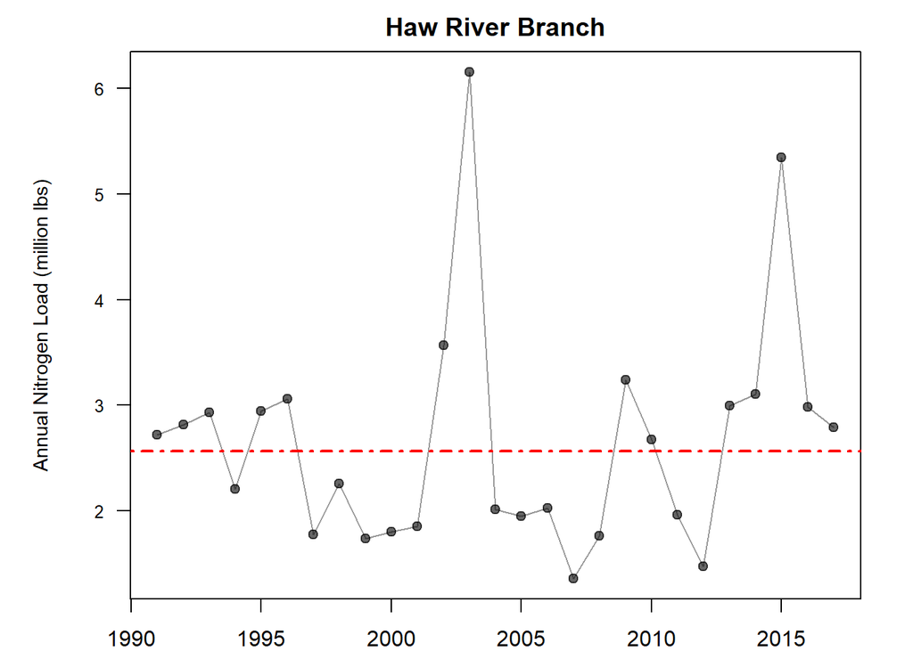

```r
#Calculate total volume of water each year
q$Flow_MGD <- 646317*q$Flow/1000000
q.year <- q %>%
  group_by(Year) %>%
  summarise(Total_MGD = sum(Flow_MGD, na.rm=T), n=n())
q.year <- as.data.frame(q.year)
q.year <- filter(q.year, n>=350)


#calculate the average Nitrate concentration
n.year <- haw.n %>%
  group_by(Year) %>%
  summarise(AveN = mean(TotalN, na.rm=T), n=n())
n.year <- as.data.frame(n.year)



#For days with a water quality measurement - what was the daily flow?
haw.n <- merge(n.year, q.year, by.x="Year", by.y="Year")
lbspergal <- 8.34
haw.n$Pounds <- haw.n$Total_MGD*haw.n$AveN*lbspergal
#convert to million pounds
haw.n$MPounds <- haw.n$Pounds/1000000

par(mfrow=c(1,1))
par(mar = c(2,5,2,2)) #set plot margins

#Plot single graph on top row.
plot(haw.n$Year, haw.n$MPounds, type='n', yaxt="n", main="Haw River Branch", ylab="Annual Nitrogen Load (million lbs)", xlab = '', cex.lab=0.9)
  axis(2, las=2, cex.axis=0.8)
  lines(haw.n$Year, haw.n$MPounds, col=rgb(0,0,0,0.4))
  points(haw.n$Year, haw.n$MPounds, col=rgb(0,0,0,0.6), cex=1, pch=19)
abline(h=2567000/1000000, col="red", lty=4, lwd=2)
```

### Calculate Annual Load for New Hope Creek

Here there are 3 upstream gauges for New Hope Creek. We will download that information into a single file. We repeat the above analyis with the New Hope stream gauges.

```r
#USGS-0209768310 is the arm of the Haw River and there are three usgs gauges upstream on different tributaries
#Identify gauges to download
siteNo <- c('02097314', '02097517','0209741955')
pcode = '00060' #discharge (cfs)
scode = "00003"  #mean
start.date = "1970-10-01"
end.date = "2017-12-31"

#Load in data using the site ID
q <- readNWISdv(siteNumbers = siteNo, parameterCd = pcode, statCd = scode, startDate=start.date, endDate=end.date)
q <- renameNWISColumns(q); colnames(q)
```

```
## [1] "agency_cd" "site_no"   "Date"      "Flow"      "Flow_cd"
```

```r
q.siteInfo <- attr(q, "siteInfo")
q$Year <- year(q$Date);  q$Month <- month(q$Date)
#If flow is unknown set to NA
q$Flow <- ifelse(q$Flow <0,NA, q$Flow)

#grab new hope monitoring station
newhope.n <- filter(df, MonitoringLocationIdentifier == "USGS-0209768310")

#where are sites located?
leaflet(data=q.siteInfo) %>%
  addProviderTiles("Esri.WorldTopoMap") %>%
  addCircleMarkers(~dec_lon_va,~dec_lat_va,
                   color = "blue", radius=3, stroke=FALSE,
                   fillOpacity = 0.8, opacity = 0.8,
                   popup=~station_nm) %>%
  addCircleMarkers(~newhope.n$LongitudeMeasure[1],~newhope.n$LatitudeMeasure[2],
                   color = "red", radius=3, stroke=FALSE,
                   fillOpacity = 0.8, opacity = 0.8,
                   popup=~newhope.n$MonitoringLocationName[1])
```

[interactive chart not shown]

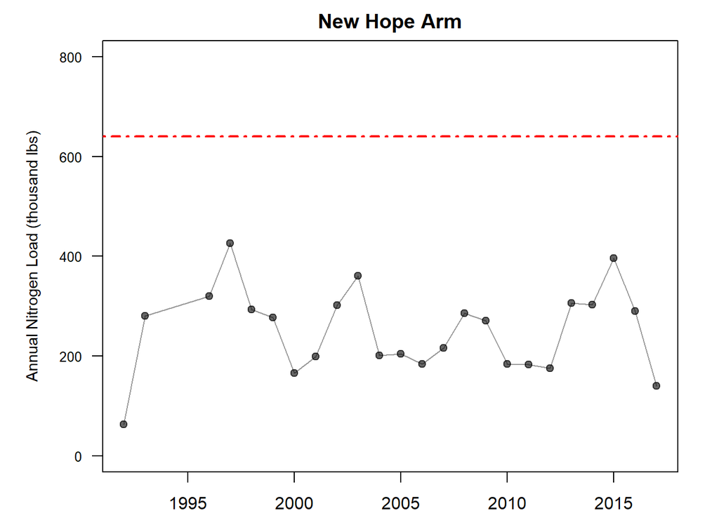

```r
#Calculate total volume of water each year
q$Flow_MGD <- 646317*q$Flow/1000000
q.year <- q %>%
  group_by(Year) %>%
  summarise(Total_MGD = sum(Flow_MGD, na.rm=T), n=n())
q.year <- as.data.frame(q.year)
q.year <- filter(q.year, n>=350*3)


#calculate the average Nitrate concentration
n.year <- newhope.n %>%
  group_by(Year) %>%
  summarise(AveN = mean(TotalN, na.rm=T), n=n())
n.year <- as.data.frame(n.year)

#For days with a water quality measurement - what was the daily flow?
newhope.n <- merge(n.year, q.year, by.x="Year", by.y="Year")
lbspergal <- 8.34
newhope.n$Pounds <- newhope.n$Total_MGD*newhope.n$AveN*lbspergal
newhope.n$KPounds <- newhope.n$Pounds/1000

par(mfrow=c(1,1))
par(mar = c(2,5,2,2)) #set plot margins

#Plot single graph on top row
plot(newhope.n$Year, newhope.n$KPounds, type='n', yaxt="n", main="New Hope Arm", ylab="Annual Nitrogen Load (thousand lbs)", xlab = '', cex.lab=0.9, ylim=c(0,800))
  axis(2, las=2, cex.axis=0.8)
  lines(newhope.n$Year, newhope.n$KPounds, col=rgb(0,0,0,0.4))
  points(newhope.n$Year, newhope.n$KPounds, col=rgb(0,0,0,0.6), cex=1, pch=19)
abline(h=641021/1000, col="red", lty=4, lwd=2)
```

Notice that the annual nitrogen load is far below the threshold level. Why or why not is this unexpected? What do you think could be causing this underestimate?

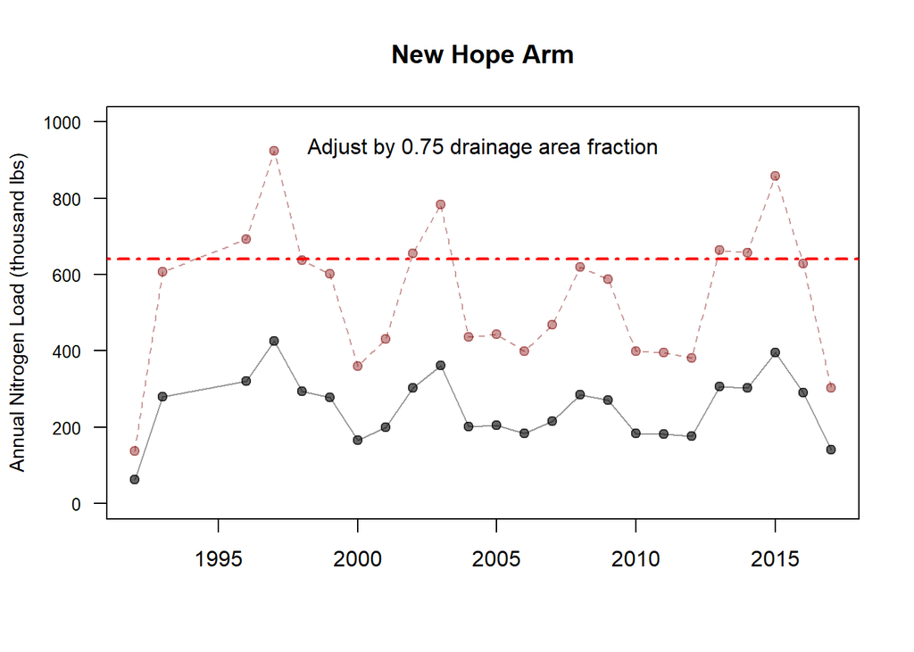

```r
site.da <- 76.9+21.2+41
remaining.da <- 1689-1275-12
fraction <- 0.75

adjust.da <- remaining.da*fraction
newhope.n$adj.pounds <- newhope.n$KPounds*adjust.da/site.da

plot(newhope.n$Year, newhope.n$adj.pounds, type='n', yaxt="n", main="New Hope Arm", ylab="Annual Nitrogen Load (thousand lbs)", xlab = '', cex.lab=0.9, ylim=c(0,1000))
axis(2, las=2, cex.axis=0.8)
  lines(newhope.n$Year, newhope.n$KPounds, col=rgb(0,0,0,0.4))
  points(newhope.n$Year, newhope.n$KPounds, col=rgb(0,0,0,0.6), cex=1, pch=19)

  lines(newhope.n$Year, newhope.n$adj.pounds, col=rgb(0.5,0,0,0.4), lty=2)
  points(newhope.n$Year, newhope.n$adj.pounds, col=rgb(0.5,0,0,0.4), cex=1, pch=19)
abline(h=641021/1000, col="red", lty=4, lwd=2)
mtext(paste0("Adjust by ", fraction, " drainage area fraction"), side=3, line=-2)
```

## Save out the new files for entry into Tableau

```r
#write csv
write.csv(df, paste0(swd,'/tableau/nitrogen.csv'),row.names=FALSE)
write.csv(haw.n, paste0(swd, '/tableau/hawbranch.csv'),row.names=FALSE)
write.csv(newhope.n, paste0(swd, '/tableau/newhope.csv'),row.names=FALSE)
```